# Drawing-Recognition-Analyses-Prereg

Bria Long

5/8/2019, updated 7/2019

# Preprocessing

## Load data

### Import recognition data from each run of recoggames: here, animalgame & vehiclegame

```r
#
animal_game <- read.csv("recognition_data/animalgame.csv") %>%
  as.tibble() %>%
  mutate(exp = 'animalgame') %>%
  select(-X)
#
vehicle_game <- read.csv("recognition_data/vehiclegame.csv") %>%
  as.tibble() %>%
  mutate(exp = 'vehiclegame') %>%
  select(-X)
#
biganimal_game <- read.csv("recognition_data/biganimalgame.csv") %>%
  as.tibble() %>%
  mutate(exp = 'biganimalgame') %>%
  select(-X)

object_game <- read.csv("recognition_data/objectgame.csv") %>%
  as.tibble() %>%
  mutate(exp = 'objectgame') %>%
  select(-X)

recog_data <- animal_game %>%
  full_join(vehicle_game)%>%
  full_join(biganimal_game) %>%
  full_join(object_game)
## make copy for editing
orig_d  <- recog_data
d <- recog_data
```

### Make variables correct types in dataset

```r
# make similar levels
d$clicked_category = as.factor(d$clicked_category)
d$intended_category = factor(d$intended_category, levels=levels(d$clicked_category))

# compute accurcy
d <- d %>%
  mutate(correct_or_not = (clicked_category == intended_category))  %>%
  mutate(recognizer_age_numeric = str_split_fixed(recognizer_age, 'age',2)[,2])

d$recognizer_age <- factor(d$recognizer_age, levels = c('age2','age3','age4','age5','age6','age7','age8','age9','age10','adult'))
```

## Data filtering

### Filter non-compliant subjects & trials:

```r
##Filter out adults, those that didn't get past more than 1 real trial, and trials with RTs that are way too long or short

adults <- d %>%
  filter(recognizer_age == 'adult')

didnt_start <- d %>%
  group_by(sessionId) %>%
  mutate(count_trials = max(trial_num)) %>%
  filter(count_trials < 5)

# do actual filtering here
d <- d %>%
  filter(!sessionId %in% didnt_start$sessionId) %>%
  filter(!sessionId %in% adults$sessionId) %>%
  filter(RT>100 & RT<10000) # super long or super short trial
```

### Calculate performance on photo catch trials; visualize for each subject; compile list of off-task subjects

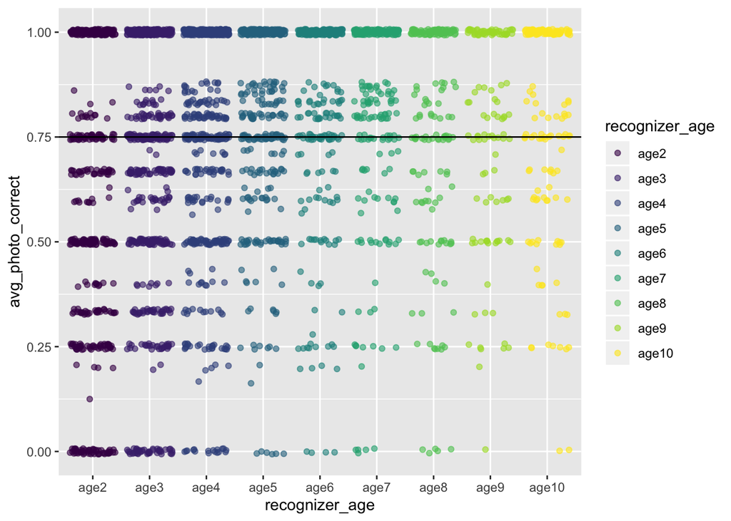

```r
# threshold : 75% correct
threshold=.75

# compute avg correct photo trials for each subject
photo_correct <- d %>%
  group_by(sessionId,recognizer_age) %>%
  filter(producer_age == "photo") %>%
  summarize(avg_photo_correct = mean(correct_or_not))

# visualize these data by each age group
ggplot(photo_correct, aes(x=recognizer_age, y=avg_photo_correct, col=recognizer_age)) +
  geom_jitter(alpha=.6) +
  scale_color_viridis(discrete=TRUE) +
  geom_hline(yintercept=threshold)
```

```r
# make a list of the subjects who don't meet our threshold
bad_subs <- photo_correct %>%
  filter(avg_photo_correct < threshold) ## includes subjects who got 75% correct, excludes all those below
```

### Filter out subs who don’t meet photo correct threshold

```r
# filter bad subs
d <- d %>%
  filter(!sessionId %in% bad_subs$sessionId)

# check that we did this right
photo_trials_by_sub <- d %>%
  filter(producer_age == 'photo') %>%
  group_by(sessionId) %>%
  summarize(avg_correct = mean(correct_or_not))

# make sure this is true.
assert_that(sum(photo_trials_by_sub$avg_correct<threshold)==0)
```

```
## [1] TRUE
```

### Finally, filter kids that didn’t have valid trials on both photo/sketch trials

```r
cor_by_trial_type <- d %>%
  mutate(photo_or_not = (producer_age == 'photo')) %>%
  group_by(photo_or_not,sessionId) %>%
  summarize(count_cor = sum(correct_or_not), count_items = n(), avg_correct = count_cor / count_items)

only_one_type <- cor_by_trial_type %>%
  group_by(sessionId) %>%
  summarize(count_ids = n()) %>%
  filter(count_ids == 1)

# filter these subjects
d <- d %>%
  filter(!sessionId %in% only_one_type$sessionId)
```

### Calculate number of trials per kid (not adult) after these exclusions and report exclusions

```r
num_trials_per_kid <- d %>%
  # filter(!sessionId %in% adults$sessionId) %>% # exclude adults (prereg code, error)
  filter(recognizer_age != "adult") %>% # exclude adults
  group_by(sessionId) %>%
  summarize(max_trials = max(trial_num)) %>%
  summarize(average_trials = mean(max_trials))

num_kids_per_exp <- d %>%
  filter(recognizer_age != "adult") %>% # exclude adults
  group_by(exp,recognizer_age) %>%
  summarize(num_subs = length(unique(sessionId)))

##
```

First, we excluded children who started the game but did not complete more than 1 trial after the practice trials (N = 1068 participants) and the 238 adults who participated. We also excluded all trials with RTs slower than 10s or faster than 100ms, judging these to be off-task responses. Next, we excluded participants on the basis of their performance on practice and catch trials; given that these catch trials presented a very easy recognition task, we excluded participants who did not acheive at least 75% accuracy on these trials (N= 1064). The remaining 1975 who met this criterion completed an average of 20.98 trials. On total, we analyzed 38913 trials where children recognized each others drawings.

### Exclusion rates in each age bin; see that we are mostly filtering out young kids not on task.

```r
bad_subs_descriptives <- orig_d %>%
  filter(sessionId %in% bad_subs$sessionId) %>%
  group_by(sessionId) %>%
  summarize(count_trials = n(), recognizer_age = recognizer_age[1]) %>%
  group_by(recognizer_age) %>%
  summarize(count_subs = n(), avg_trials = mean(count_trials))

kable(bad_subs_descriptives)
```

| recognizer_age | count_subs | avg_trials |
| --- | --- | --- |
| age10 | 46 | 19.19565 |
| age2 | 269 | 10.82528 |
| age3 | 270 | 14.37778 |
| age4 | 180 | 16.18889 |
| age5 | 103 | 21.38835 |
| age6 | 60 | 20.16667 |
| age7 | 50 | 17.58000 |
| age8 | 49 | 17.34694 |
| age9 | 37 | 15.45946 |

### Calculate number of subs left in each age

```r
d %>%
  group_by(recognizer_age) %>%
  summarize(num_subs = length(unique(sessionId))) %>%
  kable()
```

| recognizer_age | num_subs |
| --- | --- |
| age2 | 186 |
| age3 | 329 |
| age4 | 408 |
| age5 | 301 |
| age6 | 227 |
| age7 | 188 |
| age8 | 131 |
| age9 | 84 |
| age10 | 121 |

## First set of descriptives

### How are recognizers doing on photo trials aross age? Looks pretty flat.

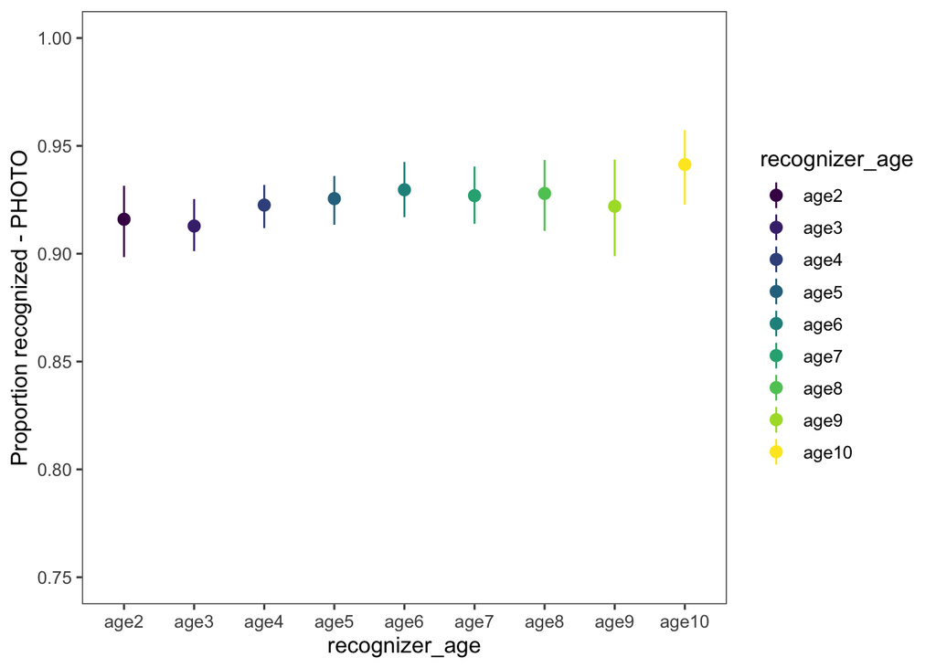

```r
by_recognizer_photo <- d %>%
  group_by(recognizer_age) %>%
  filter(producer_age == 'photo') %>%
  group_by(sessionId,recognizer_age) %>%
  summarize(indiv_photo_correct = mean(correct_or_not)) %>% # average first over individual participants
  group_by(recognizer_age) %>%
  multi_boot_standard(col = 'indiv_photo_correct')

by_recognizer_photo$recognizer_age <- factor(by_recognizer_photo$recognizer_age, levels = c('age2','age3','age4','age5','age6','age7','age8','age9','age10','adult'))

ggplot(by_recognizer_photo,aes(x=recognizer_age, y=mean, col = recognizer_age)) +
  geom_pointrange(aes(ymin = ci_lower, ymax = ci_upper)) +
  scale_color_viridis(discrete = "TRUE") +
  ylab('Proportion recognized - PHOTO') +
  ylim(.75,1) + # can't be lower than 75% correct or higher than 1
  theme_few()
```

### Look at overall recognition by recognizer age; looks like we should exclude 2 year-olds.

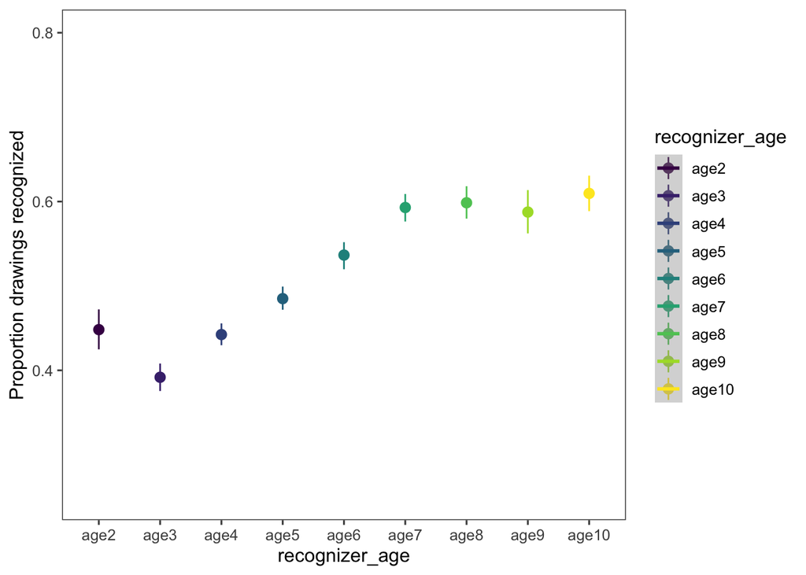

```r
by_recognizer <- d %>%
  group_by(recognizer_age) %>%
  filter(producer_age != 'photo') %>%
  multi_boot_standard(col = 'correct_or_not')

# make levels in reasonable order
by_recognizer$recognizer_age <- factor(by_recognizer$recognizer_age, levels = c('age2','age3','age4','age5','age6','age7','age8','age9','age10','adult'))

ggplot(by_recognizer,aes(x=recognizer_age, y=mean, col = recognizer_age)) +
  theme_few() +
  geom_pointrange(aes(ymin = ci_lower, ymax = ci_upper)) +
  scale_color_viridis(discrete = "TRUE") +
  ylab('Proportion drawings recognized') +
  ylim(.25,.8) +
  geom_smooth()
```

### Look at use of “don’t know” buton across age; roughly goes down with recognizer age.

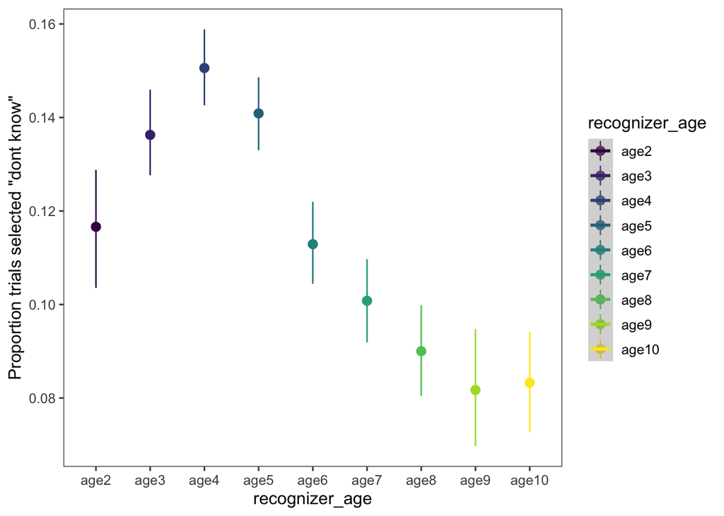

```r
by_recognizer_dont_know <- d %>%
  mutate(dont_know = (clicked_category == 'dont_know')) %>%
  group_by(recognizer_age) %>%
  multi_boot_standard(col = 'dont_know')

ggplot(by_recognizer_dont_know,aes(x=recognizer_age, y=mean, col = recognizer_age)) +
  theme_few() +
  geom_pointrange(aes(ymin = ci_lower, ymax = ci_upper)) +
  scale_color_viridis(discrete = "TRUE") +
  ylab('Proportion trials selected "dont know"') +
  geom_smooth()
```

## Updated filtering

For later, fine-grain analyses: given uneven distribution of subjects and performance from 2-year-olds, create new age bins that (1) exclude 2-year-olds and (2) group together older kids.

```r
## filter recognition data to just kids and wrangle variables
kids_sketches_d <- d %>%
  filter(producer_age != 'photo') %>% # don't look at photo trials
  filter(recognizer_age != 'age2') %>%  # or 2-yr-olds
  mutate(recognizer_age_numeric = as.numeric(str_split_fixed(recognizer_age,'age',2)[,2])) %>%
  mutate(recognizer_age_group = cut(recognizer_age_numeric, c(2.9, 4, 6, 8, 10.1), labels = c("3-4 yrs","5-6 yrs","7-8 yrs","9-10 yrs"))) %>%
  mutate(recognizer_age_group_numeric = cut(recognizer_age_numeric, c(2.9, 4, 6, 8, 10.1), labels=c(3,5,7,9))) %>%
  mutate(recognizer_age_group_numeric = as.numeric(recognizer_age_group_numeric))
```

### And wrangle sketch paths so can be joined with classification data outputs

```r
kids_sketches_d <- kids_sketches_d %>%
  mutate(sketch_path = as.factor(str_split_fixed(sketch_path,'/',2)[,2])) %>%
  mutate(sketch_path = as.factor(str_split_fixed(sketch_path,'.png',2)[,1]))
```

### Now also look at number of included subjects in each age group and experiment

```r
kids_sketches_d %>%
  group_by(recognizer_age_group,exp) %>%
  summarize(num_subs = length(unique(sessionId))) %>%
  kable()
```

| recognizer_age_group | exp | num_subs |
| --- | --- | --- |
| 3-4 yrs | animalgame | 111 |
| 3-4 yrs | biganimalgame | 211 |
| 3-4 yrs | objectgame | 291 |
| 3-4 yrs | vehiclegame | 124 |
| 5-6 yrs | animalgame | 63 |
| 5-6 yrs | biganimalgame | 174 |
| 5-6 yrs | objectgame | 190 |
| 5-6 yrs | vehiclegame | 101 |
| 7-8 yrs | animalgame | 33 |
| 7-8 yrs | biganimalgame | 81 |
| 7-8 yrs | objectgame | 137 |
| 7-8 yrs | vehiclegame | 68 |
| 9-10 yrs | animalgame | 37 |
| 9-10 yrs | biganimalgame | 57 |
| 9-10 yrs | objectgame | 77 |
| 9-10 yrs | vehiclegame | 34 |

# Basic descriptives and plots

## Examine recognition data

### Examine recognition by recognizer’s age and experiment run

```r
by_recognizer_filtered <- kids_sketches_d %>%
  group_by(recognizer_age, recognizer_age_numeric,exp) %>%
  multi_boot_standard(col = 'correct_or_not')

count_trials <- kids_sketches_d %>%
  group_by(recognizer_age) %>%
  summarize(count_trials = n())

by_recognizer_filtered$recognizer_age <- factor(by_recognizer_filtered$recognizer_age, levels = c('age2','age3','age4','age5','age6','age7','age8','age9','age10','adult'))

## Scale dots by number of trials in each bin to get a sense of variability
by_recognizer_filtered <-  by_recognizer_filtered %>%
  left_join(count_trials) %>%
  mutate(scale = count_trials / 1000) %>%
  group_by(exp)
```

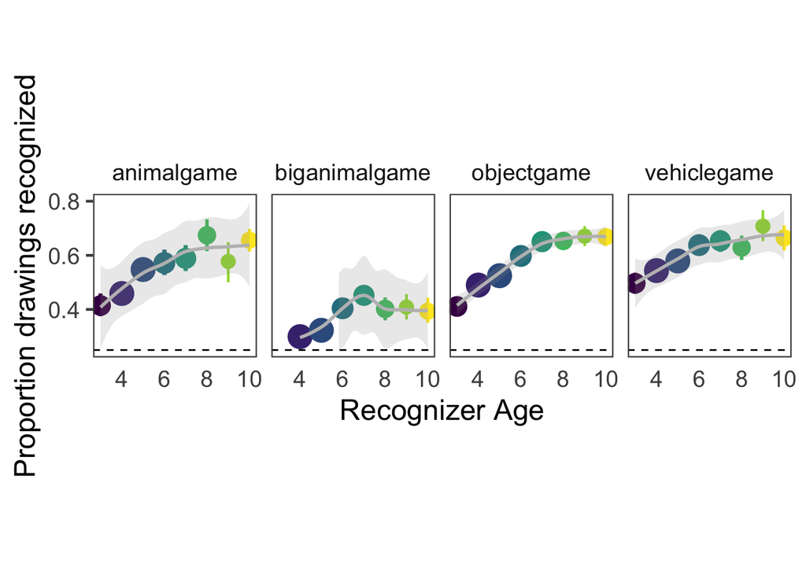

```r
ggplot(by_recognizer_filtered,aes(x=recognizer_age_numeric, y=mean, col = recognizer_age_numeric, size=scale)) +
  theme_few(base_size=18) +
  geom_pointrange(aes(ymin = ci_lower, ymax = ci_upper)) +
  geom_smooth(alpha=.2, color='grey') +
  scale_color_viridis(discrete = "FALSE") +
  ylab('Proportion drawings recognized') +
  scale_size_area(max_size=1.5) +
  ylim(.25,.8) +
  xlab('Recognizer Age') +
  geom_hline(yintercept = .25, linetype="dashed") +
  theme(axis.ticks.x = element_blank(), legend.position='none', aspect.ratio = 1) +
  facet_grid(~exp)
```

### Also visualize by recognizer age GROUP x experiment run

```r
## Doesn't seem quite right because there are such vastly different numbers of trials per kid.
# by_recognizer_filtered_age_group <- kids_sketches_d %>%
#   group_by(sessionId,recognizer_age_group,recognizer_age_group_numeric,exp) %>%
#   summarize(indiv_photo_correct = mean(correct_or_not)) %>% # average first over individual participants
#   group_by(recognizer_age_group, recognizer_age_group_numeric,exp) %>%
#   multi_boot_standard(col = 'indiv_photo_correct')
#
# count_subs_age_group <- kids_sketches_d %>%
#   distinct(sessionId,recognizer_age_group) %>%
#   group_by(recognizer_age_group) %>%
#   summarize(count_subs = n())

by_recognizer_filtered_age_group <- kids_sketches_d %>%
  group_by(recognizer_age_group,recognizer_age_group_numeric,exp) %>%
  multi_boot_standard(col = 'correct_or_not')

count_trials_age_group <- kids_sketches_d %>%
  group_by(recognizer_age_group) %>%
  summarize(count_trials = n())

## Scale dots by number of trials in each bin to get a sense of variability
by_recognizer_filtered_age_group <-  by_recognizer_filtered_age_group %>%
  left_join(count_trials_age_group) %>%
  mutate(scale = count_trials) %>%
  group_by(exp)
```

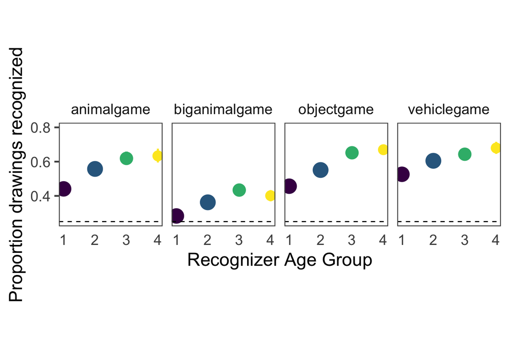

```r
ggplot(by_recognizer_filtered_age_group,aes(x=recognizer_age_group_numeric, y=mean, col = recognizer_age_group_numeric, size=scale)) +
  theme_few(base_size=18) +
  geom_pointrange(aes(ymin = ci_lower, ymax = ci_upper)) +
  # geom_smooth(alpha=.2, color='grey') +
  scale_color_viridis(discrete = "FALSE") +
  ylab('Proportion drawings recognized') +
  scale_size_area(max_size=1.5) +
  ylim(.25,.8) +
  xlab('Recognizer Age Group') +
  geom_hline(yintercept = .25, linetype="dashed") +
  theme(axis.ticks.x = element_blank(), legend.position='none', aspect.ratio = 1) +
  facet_grid(~exp)
```

### How does recognition vary with the age of the PRODUCER of the drawing? Goes up, as we would expect

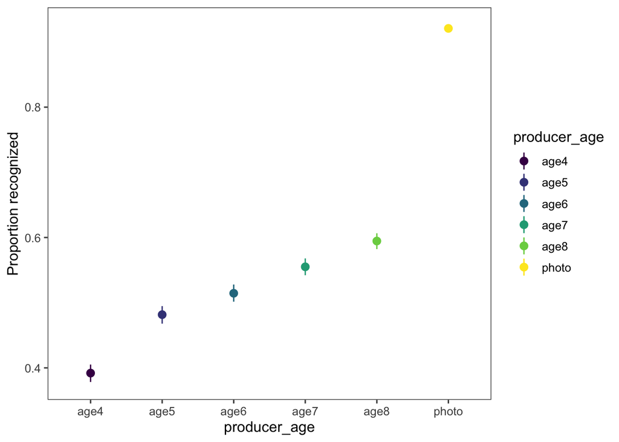

```r
# summarize avg correct by producer age
by_producer <- d %>%
  filter(recognizer_age!= 'adult') %>%
  group_by(producer_age) %>%
  multi_boot_standard(col = 'correct_or_not')

ggplot(by_producer,aes(x=producer_age, y=mean, col = producer_age)) +
  geom_pointrange(aes(ymin = ci_lower, ymax = ci_upper)) +
  scale_color_viridis(discrete = "TRUE") +
  ylab('Proportion recognized') +
  theme_few()
```

### How does recognition break down by each category?

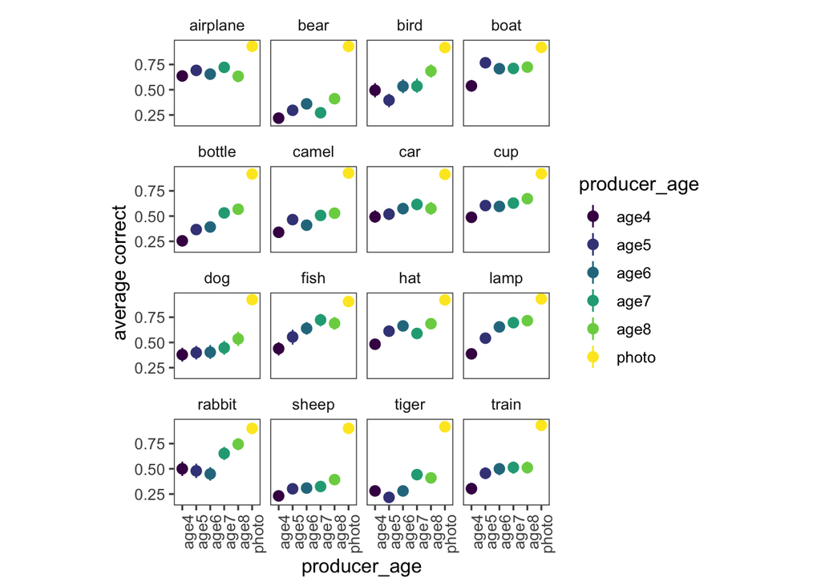

```r
both_category <- d %>%
  group_by(producer_age,intended_category) %>%
  multi_boot_standard(col = 'correct_or_not')

ggplot(both_category,aes(x=producer_age, y=mean, col=producer_age)) +
  theme_few() +
  geom_pointrange(aes(ymin = ci_lower, ymax = ci_upper)) +
  ylab('average correct') +
  theme(axis.text.x = element_text(angle = 90, hjust = 1), aspect.ratio = 1) +
  facet_wrap(~intended_category) +
  scale_color_viridis(discrete=TRUE)
```

## Compute and plot recognition by sketch distinctiveness

We expect that the distintiveness of each drawing will be a major factor in how well it is recognized, and, further, that older children will be more sensitive to the presence of these distinctive features.

### Import classifications data (4-way classifications separetly for each run of recoggames)

```r
c_vehiclegame <- read.csv("compiled_classifications/classification-outputs-vehiclegame_C_0.1_460.csv") %>%
  as.tibble() %>%
  select(-X.1, -X) %>%
  mutate(denom = (airplane_prob + train_prob + boat_prob + car_prob) - target_label_prob) %>%
  mutate(log_odds = log(target_label_prob / denom)) %>% ## compute log odd probability
  mutate(exp='vehiclegame')

# now read it and join with other classifications
c_animalgame <- read.csv("compiled_classifications/classification-outputs-animalgame_C_0.1_560.csv") %>%
  as.tibble() %>%
  select(-X.1, -X) %>%
  mutate(denom = (dog_prob + fish_prob + rabbit_prob + bird_prob) - target_label_prob) %>%
  mutate(log_odds = log(target_label_prob / denom)) %>%
  mutate(exp='animalgame')

#
c_biganimalgame <- read.csv("compiled_classifications/classification-outputs-biganimalgame_C_0.1_600.csv") %>%
  as.tibble() %>%
  select(-X.1, -X) %>%
  mutate(denom = (bear_prob + sheep_prob + camel_prob + tiger_prob) - target_label_prob) %>%
  mutate(log_odds = log(target_label_prob / denom)) %>%
  mutate(exp='animalgame')


# now read it and join with other classifications
c <- read.csv("compiled_classifications/classification-outputs-objectgame_C_0.1_500.csv") %>%
  as.tibble() %>%
  select(-X.1, -X) %>%
  mutate(denom = (bottle_prob + lamp_prob + hat_prob + cup_prob) - target_label_prob) %>%
  mutate(log_odds = log(target_label_prob / denom)) %>%
  mutate(exp='objectgame') %>%
  full_join(c_vehiclegame) %>%
  full_join(c_animalgame) %>%
  full_join(c_biganimalgame) %>%
  mutate(sketch_path = paste0(target_label,'_','sketch_age',age,'_cdm_',session_id)) %>%
  mutate(sketch_path = as.factor(sketch_path))
```

### Check how log-odds varies with target label probability and classifier outcome

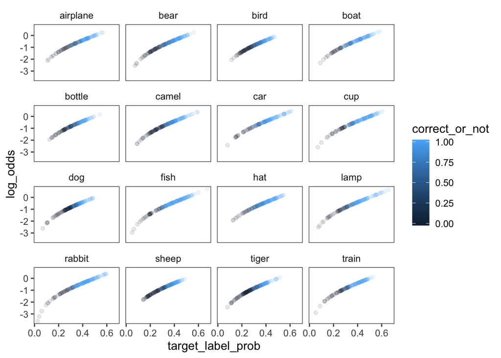

```r
ggplot(c, aes(x=target_label_prob, y=log_odds, col=correct_or_not)) +
  geom_jitter(alpha=.1) +
  facet_wrap(~target_label) +
  theme_few()
```

## Compute distincitveness bins, join classifications & recognition data

```r
num_bins=10

## compute bins for distinctiveness
sketch_by_distinctiveness <- c %>%
  mutate(distinct_index = ntile(log_odds,num_bins)) %>% ## compute bins based on log odds over entire dataset
  select(sketch_path, distinct_index, log_odds)

## join distinctiveness bins for each sketch in dataset
all_joined <- kids_sketches_d %>%
  left_join(sketch_by_distinctiveness)
```

## How does distinctiveness bin vary with classifier probability /correctness?

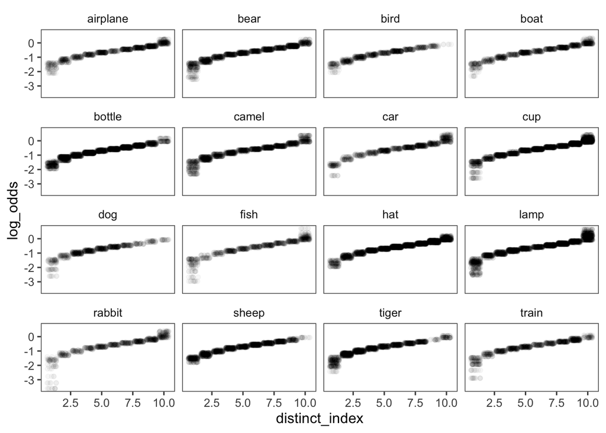

```r
ggplot(all_joined, aes(x=distinct_index, y=log_odds)) +
  geom_jitter(alpha=.03) +
  facet_wrap(~intended_category) +
  theme_few()
```

### Plot distinctivenss by item effects

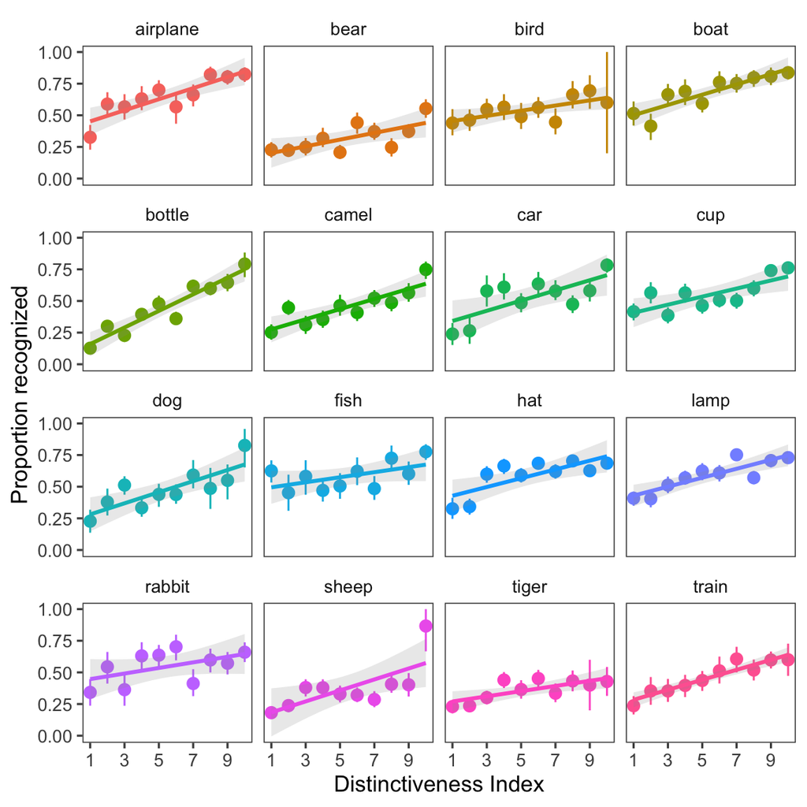

```r
distinct_by_item <- all_joined %>%
  group_by(intended_category, distinct_index) %>%
  multi_boot_standard(col='correct_or_not') %>%
  group_by(distinct_index)

ggplot(distinct_by_item, aes(x=distinct_index, y=mean, col=intended_category)) +
  geom_pointrange(aes(ymin = ci_lower, ymax = ci_upper)) +
  geom_smooth(alpha=.2, span=10, method='lm') +
  theme_few() +
  scale_x_continuous(breaks=seq(1,10,2)) +
  xlab('Distinctiveness Index') +
  ylab('Proportion recognized') +
  theme(legend.position='none') +
  facet_wrap(~intended_category)
```

### Plot distinctivenss by age interaction

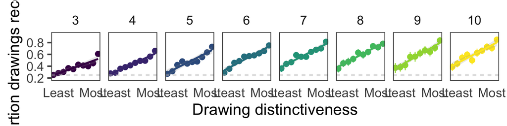

```r
distinct_by_age <- all_joined %>%
  group_by(recognizer_age_numeric, distinct_index) %>%
  multi_boot_standard(col='correct_or_not') %>%
  group_by(distinct_index)

ggplot(distinct_by_age, aes(x=distinct_index, y=mean, col=recognizer_age_numeric)) +
  geom_pointrange(aes(ymin = ci_lower, ymax = ci_upper)) +
  geom_smooth(alpha=.2, span=10, method='lm') +
  facet_grid(~recognizer_age_numeric) +
  theme_few(base_size=18) +
  theme(legend.position="none") +
  geom_hline(yintercept=.25, linetype='dashed',color='grey') +
  xlab('Drawing distinctiveness') +
  ylab('Proportion drawings recognized') +
  scale_color_viridis(discrete=FALSE) +
  scale_x_continuous(
    breaks=c(2,9),
    # labels=c('Least \n distinctive','Most \n distinctive')
    labels=c(' Least ',' Most ')
        ) +
  theme(axis.ticks.x=element_blank())
```

### Plot distinctivenss by age group interaction

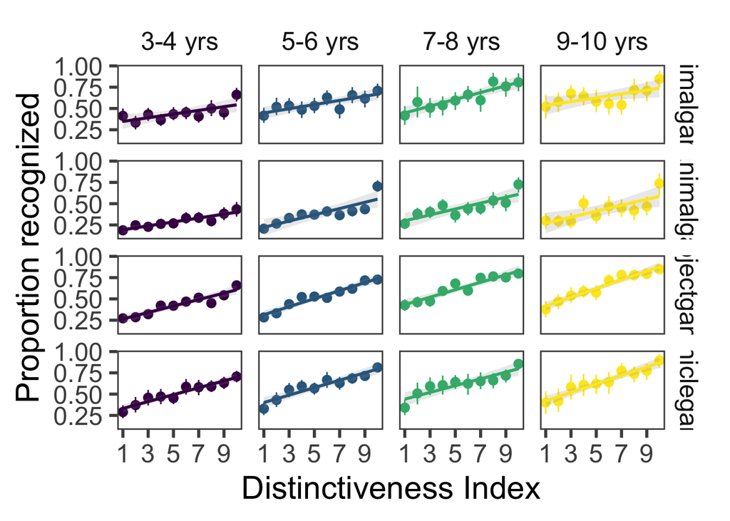

```r
distinct_by_age <- all_joined %>%
  group_by(recognizer_age_group, distinct_index, exp) %>%
  multi_boot_standard(col='correct_or_not') %>%
  group_by(distinct_index)

(distinct_by_age_plot <- ggplot(distinct_by_age, aes(x=distinct_index, y=mean, col=recognizer_age_group)) +
  geom_pointrange(aes(ymin = ci_lower, ymax = ci_upper)) +
  geom_smooth(alpha=.2, span=4, method='lm') +
  facet_grid(exp ~ recognizer_age_group) +
  theme_few(base_size = 22) +
  scale_x_continuous(breaks=seq(1,10,2)) +
  xlab('Distinctiveness Index') +
  ylab('Proportion recognized') +
  theme(legend.position='none') +
  scale_color_viridis(discrete=TRUE))
```

```r
# ggsave('DistinctByAge.svg',distinct_by_age_plot, width=11)
```

# Inferential statistics

### Examine how distinctivenss vs age group interact in glmer

```r
model_glmer <- glmer(correct_or_not ~ scale(distinct_index)*scale(recognizer_age_group_numeric) + (distinct_index|intended_category) + (1|sessionId),  data = all_joined, family='binomial')
summary(model_glmer)
```

```
## Generalized linear mixed model fit by maximum likelihood (Laplace
##   Approximation) [glmerMod]
##  Family: binomial  ( logit )
## Formula:
## correct_or_not ~ scale(distinct_index) * scale(recognizer_age_group_numeric) +
##     (distinct_index | intended_category) + (1 | sessionId)
##    Data: all_joined
##
##      AIC      BIC   logLik deviance df.resid
##  34122.7  34188.4 -17053.3  34106.7    27250
##
## Scaled residuals:
##     Min      1Q  Median      3Q     Max
## -3.8586 -0.8361  0.3817  0.8153  2.9487
##
## Random effects:
##  Groups            Name           Variance Std.Dev. Corr
##  sessionId         (Intercept)    0.240401 0.49031
##  intended_category (Intercept)    0.238976 0.48885
##                    distinct_index 0.002056 0.04534  -0.31
## Number of obs: 27258, groups:  sessionId, 1789; intended_category, 16
##
## Fixed effects:
##                                                           Estimate
## (Intercept)                                                0.05478
## scale(distinct_index)                                      0.45519
## scale(recognizer_age_group_numeric)                        0.30671
## scale(distinct_index):scale(recognizer_age_group_numeric)  0.05515
##                                                           Std. Error
## (Intercept)                                                  0.12068
## scale(distinct_index)                                        0.03620
## scale(recognizer_age_group_numeric)                          0.01900
## scale(distinct_index):scale(recognizer_age_group_numeric)    0.01395
##                                                           z value Pr(>|z|)
## (Intercept)                                                 0.454     0.65
## scale(distinct_index)                                      12.574  < 2e-16
## scale(recognizer_age_group_numeric)                        16.142  < 2e-16
## scale(distinct_index):scale(recognizer_age_group_numeric)   3.952 7.76e-05
##
## (Intercept)
## scale(distinct_index)                                     ***
## scale(recognizer_age_group_numeric)                       ***
## scale(distinct_index):scale(recognizer_age_group_numeric) ***
## ---
## Signif. codes:  0 '***' 0.001 '**' 0.01 '*' 0.05 '.' 0.1 ' ' 1
##
## Correlation of Fixed Effects:
##             (Intr) scl(_) s(___)
## scl(dstnc_) 0.196
## scl(rcg___) 0.011  0.017
## sc(_):(___) 0.006  0.015  0.038
```

## Inferential model #2: Recognizer age as a continous variable

```r
model_glmer_age_cont <- glmer(correct_or_not ~ scale(distinct_index)*scale(recognizer_age_numeric)*exp + (distinct_index|intended_category) + (1|sessionId),  data = all_joined, family='binomial')
summary(model_glmer_age_cont)
```

```
## Generalized linear mixed model fit by maximum likelihood (Laplace
##   Approximation) [glmerMod]
##  Family: binomial  ( logit )
## Formula:
## correct_or_not ~ scale(distinct_index) * scale(recognizer_age_numeric) *
##     exp + (distinct_index | intended_category) + (1 | sessionId)
##    Data: all_joined
##
##      AIC      BIC   logLik deviance df.resid
##  34086.8  34251.0 -17023.4  34046.8    27238
##
## Scaled residuals:
##     Min      1Q  Median      3Q     Max
## -3.6860 -0.8322  0.3743  0.8183  2.9177
##
## Random effects:
##  Groups            Name           Variance  Std.Dev. Corr
##  sessionId         (Intercept)    0.2288732 0.47841
##  intended_category (Intercept)    0.1427919 0.37788
##                    distinct_index 0.0008441 0.02905  -0.64
## Number of obs: 27258, groups:  sessionId, 1789; intended_category, 16
##
## Fixed effects:
##                                                                      Estimate
## (Intercept)                                                           0.19127
## scale(distinct_index)                                                 0.30973
## scale(recognizer_age_numeric)                                         0.32293
## expbiganimalgame                                                     -0.76872
## expobjectgame                                                         0.02485
## expvehiclegame                                                        0.19293
## scale(distinct_index):scale(recognizer_age_numeric)                   0.03771
## scale(distinct_index):expbiganimalgame                                0.07187
## scale(distinct_index):expobjectgame                                   0.23879
## scale(distinct_index):expvehiclegame                                  0.24944
## scale(recognizer_age_numeric):expbiganimalgame                       -0.05900
## scale(recognizer_age_numeric):expobjectgame                           0.05698
## scale(recognizer_age_numeric):expvehiclegame                         -0.07650
## scale(distinct_index):scale(recognizer_age_numeric):expbiganimalgame  0.01732
## scale(distinct_index):scale(recognizer_age_numeric):expobjectgame     0.02890
## scale(distinct_index):scale(recognizer_age_numeric):expvehiclegame    0.02735
```

[output cut: 55 more lines]

```
## expbiganimalgame                                                     ***
## expobjectgame
## expvehiclegame
## scale(distinct_index):scale(recognizer_age_numeric)
## scale(distinct_index):expbiganimalgame
## scale(distinct_index):expobjectgame                                  **
## scale(distinct_index):expvehiclegame                                 **
## scale(recognizer_age_numeric):expbiganimalgame
## scale(recognizer_age_numeric):expobjectgame
## scale(recognizer_age_numeric):expvehiclegame
## scale(distinct_index):scale(recognizer_age_numeric):expbiganimalgame
## scale(distinct_index):scale(recognizer_age_numeric):expobjectgame
## scale(distinct_index):scale(recognizer_age_numeric):expvehiclegame
## ---
## Signif. codes:  0 '***' 0.001 '**' 0.01 '*' 0.05 '.' 0.1 ' ' 1
```

```
##
## Correlation matrix not shown by default, as p = 16 > 12.
## Use print(x, correlation=TRUE)  or
##     vcov(x)        if you need it
```

```
## convergence code: 0
## Model failed to converge with max|grad| = 0.00689637 (tol = 0.001, component 1)
```

```r
# model_glmer_age_cont <- glmer(correct_or_not ~ scale(distinct_index)*scale(recognizer_age_numeric)*exp + (1|intended_category) + (1|sessionId) + (distinct_index|exp),  data = all_joined, family='binomial')
# summary(model_glmer_age_cont)
```

```r
model_glmer_age_cont_ba_only <- glmer(correct_or_not ~ scale(distinct_index)*scale(recognizer_age_numeric) + (distinct_index|intended_category) + (1|sessionId),  data = all_joined %>% filter(exp=='biganimalgame'), family='binomial')
summary(model_glmer_age_cont_ba_only)
```

```
## Generalized linear mixed model fit by maximum likelihood (Laplace
##   Approximation) [glmerMod]
##  Family: binomial  ( logit )
## Formula:
## correct_or_not ~ scale(distinct_index) * scale(recognizer_age_numeric) +
##     (distinct_index | intended_category) + (1 | sessionId)
##    Data: all_joined %>% filter(exp == "biganimalgame")
##
##      AIC      BIC   logLik deviance df.resid
##   8946.7   9001.8  -4465.4   8930.7     7226
##
## Scaled residuals:
##     Min      1Q  Median      3Q     Max
## -2.1340 -0.7137 -0.5312  1.0126  2.8530
##
## Random effects:
##  Groups            Name           Variance  Std.Dev. Corr
##  sessionId         (Intercept)    0.2701748 0.51978
##  intended_category (Intercept)    0.0202557 0.14232
##                    distinct_index 0.0004036 0.02009  1.00
## Number of obs: 7234, groups:  sessionId, 523; intended_category, 4
##
## Fixed effects:
##                                                     Estimate Std. Error
## (Intercept)                                         -0.68224    0.12627
## scale(distinct_index)                                0.36871    0.03904
## scale(recognizer_age_numeric)                        0.23740    0.03678
## scale(distinct_index):scale(recognizer_age_numeric)  0.05127    0.02682
##                                                     z value Pr(>|z|)
## (Intercept)                                          -5.403 6.55e-08 ***
## scale(distinct_index)                                 9.444  < 2e-16 ***
## scale(recognizer_age_numeric)                         6.455 1.08e-10 ***
## scale(distinct_index):scale(recognizer_age_numeric)   1.912   0.0559 .
## ---
## Signif. codes:  0 '***' 0.001 '**' 0.01 '*' 0.05 '.' 0.1 ' ' 1
##
## Correlation of Fixed Effects:
##             (Intr) scl(_) sc(__)
## scl(dstnc_)  0.669
## scl(rcgn__)  0.004  0.015
## scl(_):(__)  0.006 -0.027 -0.034
## convergence code: 0
## Model failed to converge with max|grad| = 0.0105581 (tol = 0.001, component 1)
```